# pandas中的绘图函数

Series和DataFrame都有一个用于生成各类图表的plot方法。默认情况下，它们所生成的是线形图

```python
import numpy as np
import pandas as pd
from pandas import Series,DataFrame
import matplotlib.pyplot as plt
```

## 线形图

简单的DataFrame图表示例,plot()

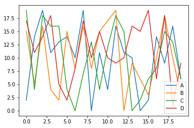

```python
df = DataFrame(np.random.randint(0,20,size=(20,4)),columns=list('ABCD'))
df.plot()
```

## 柱状图

DataFrame柱状图示例

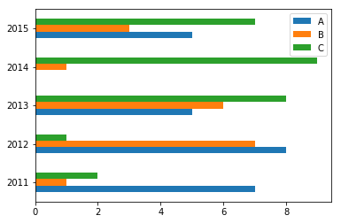

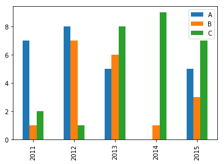

```python
df = DataFrame(np.random.randint(0,10,size=(5,3)),columns=list('ABC'),index=[2011,2012,2013,2014,2015])
df.plot(kind='barh')
df.plot(kind='bar')
```

## 直方图

rondom生成随机数百分比直方图，调用hist方法

```
array([[<matplotlib.axes._subplots.AxesSubplot object at 0x00000189292C3160>]],
      dtype=object)
```

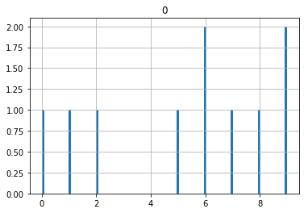

```python
# 表示的是出现的次数
df = DataFrame(np.random.randint(0,10,size=10))
df.hist(bins=100)
```

随机数百分比密度图s.plot(kind = 'kde')

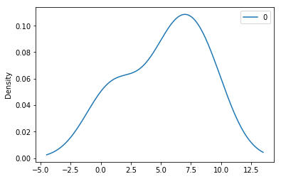

```python
df.plot(kind='kde')
```

np.random.normal()正太分布函数

直方图hist，函数中必须添加属性normed = True

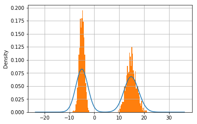

```python
n1 = np.random.normal(-5,scale=1,size=1000)
n2 = np.random.normal(15,scale=2,size=1000)
n = np.concatenate([n1,n2])
s = Series(n)
s.plot(kind='kde')
s.hist(bins=100,normed=True)
```

## 散布图

散布图 散布图是观察两个一维数据数列之间的关系的有效方法

注意使用kind = 'scatter'时，给明标签columns

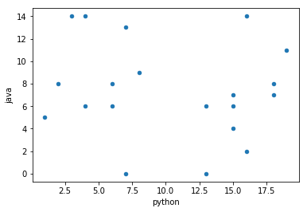

```python
df = DataFrame(np.random.randint(0,20,size=(20,3)),columns=['python','java','c'])
df.plot(kind='scatter',x='python',y='java')
```

```python
df['math'] = df['python'].map(lambda x:2*x+np.random.randint(-5,5,size=1)[0])
```

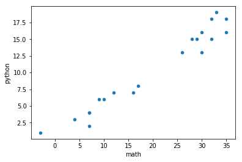

```python
df.plot(kind='scatter',x='math',y='python')
```

散布图矩阵，当有多个点时，两两点的关系

函数：pd.plotting.scatter_matrix(),注意参数diagnol：对角线

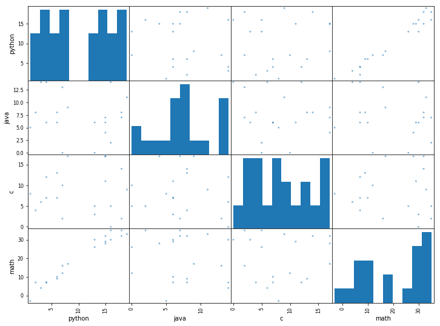

```python
a = pd.plotting.scatter_matrix(df,figsize=(12,9))
```